# Introduction to Statistical Methods

Augustin Luna  
26 January, 2016

Research Fellow  
Department of Biostatistics and Computational Biology  
Dana-Farber Cancer Institute

### Topics to be Covered

- Correlations
- Enrichment Analyses
- Multiple Testing Correction
- Regression
- Clustering
- Dimensionality Reduction

### Introduction

- Data analyses are the product of many tasks
- Statistical Methods
  - Build predictive mathematical models
- Data preparation
  - Extracting structured data from unstructured data sources
  - Merging data sources
  - Ensuring consistency of datasets
- Dataset interpretation
  - Create visualizations to present and communicate findings
- Methods are common in the areas of informatics, data mining, data science, machine learning, and statistics

### Statistical Methods Flowchart

- The flowchart below helps find the right method for a given problem
  - http://scikit-learn.org/stable/tutorial/machine_learning_map/

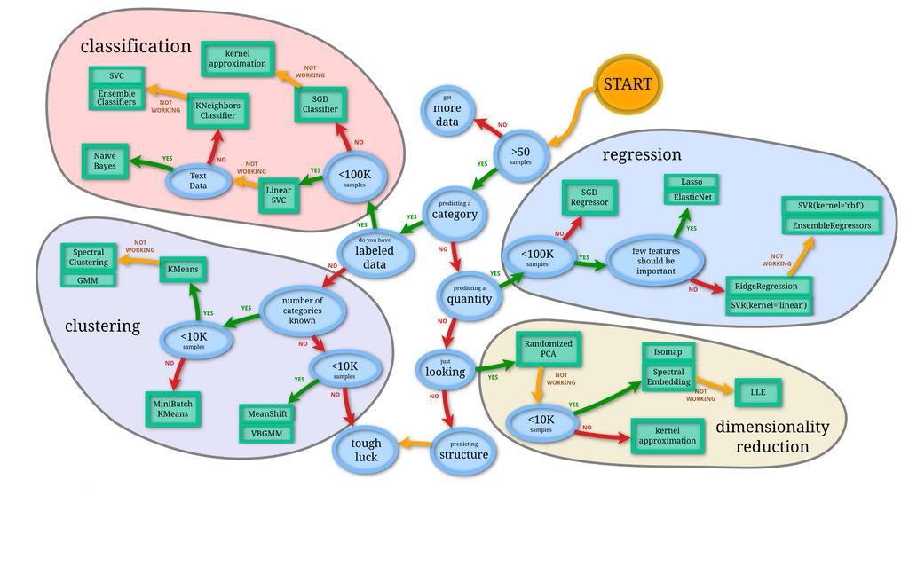

### Methods to be Covered

- Basic method will be covered to build confidence with R and the general concepts
  - Dimensionality Reduction: Principal Component Analysis (PCA)
  - Regression: Linear regression
  - Clustering: Hierarchical and K-means clustering
  - Classification will not be covered

### Correlating Two Vectors

```r
# Make sure the random numbers are always the same
set.seed(1)

# Generate two sets of 20 random numbers
a <- runif(20); b <- runif(20)

# Calulate the correlation of the two sets
cor.test(a, b)
```

```
    Pearson's product-moment correlation

data:  a and b
t = -1.0368, df = 18, p-value = 0.3136
alternative hypothesis: true correlation is not equal to 0
95 percent confidence interval:
 -0.6152730  0.2292138
sample estimates:
       cor
-0.2373854
```

### Extracting Values From Results

- Values in results are described in the help `?cor.test`
- A p-value is the probability of seeing results as extreme as the ones produced in an analysis.

```r
set.seed(1)

a <- runif(20)
b <- runif(20)

results <- cor.test(a, b, method="pearson")
names(results)
```

```
[1] "statistic"   "parameter"   "p.value"     "estimate"    "null.value"
[6] "alternative" "method"      "data.name"   "conf.int"
```

```r
results$p.value
```

```
[1] 0.3135682
```

### Over-Representation (ORA) and Enrichment Analyses

- Enrichment tests are widely used in biology to determine if the genes contain a trait more frequently than a random sampling of genes
  - Gene Ontology (GO) term (e.g. biological process, molecular function, or cellular component) and pathways are the most common comparisons made
- Several tools exist for doing enrichment analyses
  - The tests are either Fisher's exact test or hypergeometric test; these tests produce the same results
  - These calculations can be done in R using `fisher.test` and `phyper`

### Enrichment Analysis

- What is the probability of randomly drawing at least 4 black points in a random sample of 10 points?
  - The concept of “black” could be replaced by “genes from a given pathway” or “genes with a common function”

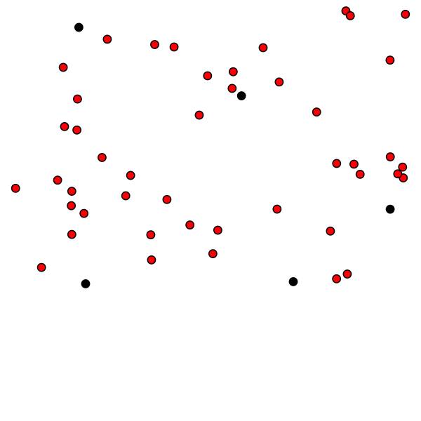

### Calculating an ORA (Enrichment) P-Value

The significance (i.e. p-value \( P(X \geq k) \)) of an over-representation (enrichment analysis) is calculated using a hypergeometric test:

\[ \begin{align} P(X \geq k) = 1 - \sum_{i=0}^{k-1}{\frac{\binom{K}{i}\binom{N-K}{n-i}}{\binom{N}{n}}} \end{align} \]

where

- N: number of studied genes,
- n: total number of genes identified by a previous analysis
- K: total number of genes in with an annotation
- k: number genes previously identified genes with the annotation
- \( \binom{n}{k} \): the number of of ways of choosing \( k \) elements from a set of \( n \) elements, disregarding order

The p-value of this test indicates the probability that a random selection of genes of the same size as the input gene set from a population would produce the same number of observed annotations (e.g. for a specific GO term or pathway) or more in the gene set

### Choose k from N Without Order

```r
N <- 5
k <- 3
factorial(N) / (factorial(k)*factorial(N-k))
```

```
[1] 10
```

```r
N <- 5
k <- 3
choose(N, k)
```

```
[1] 10
```

### Contingency Table for Enrichment Analysis

|  | Drawn | Not Drawn | Total |
| --- | --- | --- | --- |
| Black | k=4 | K-k=1 | K=5 |
| Red | n-k=6 | N+k-n-K=39 | N-K=45 |
| Total | n=10 | N-n=40 | N=50 |

### phyper or fisher.test Example

- NOTE: `hitInSample-1` is nescessary in `phyper` beacuse if `lower.tail` is FALSE, probabilities returned are P(X > k). Subtract k by 1 to get P(X ≥ k) (k equal to or greater than).

```r
sampleSize <- 10 # size drawn
hitInSample <- 4 # black drawn
hitInPop <- 5 # all black
failInPop <- 50-hitInPop # number of red

phyper(hitInSample-1, hitInPop, failInPop, sampleSize, lower.tail= FALSE);
```

```
[1] 0.004083521
```

```r
fisher.test(matrix(c(hitInSample, hitInPop-hitInSample, sampleSize-hitInSample, failInPop-sampleSize+hitInSample), 2, 2), alternative='greater')$p.value;
```

```
[1] 0.004083521
```

### Multiple Testing Correction for Enrichment Analyses

- Enrichment analyses often do analyses over a large number of molecular functions or pathways
- If we conduct many such tests, we are likely to see false positives
  - A p-value significance cutoff of 0.05 means that we expect 1 test out of 20 to appear significant by random chance (i.e. a false positive)

### Multiple Test Corrections Types

- Family-Wise Error Rate (FWER): Controls the probability that any test is a false positive
  - Bonferroni Correction: Very stringent correction; the significance cutoff (i.e. \( \alpha \)) is adjusted by the number of tests conducted

  \[ \begin{align} \alpha_{new} = \frac{\alpha}{n} \end{align} \]
  - \( \alpha = 0.05 \) and 10 tests is adjusted to \( \alpha = 0.005 \)
- False Discovery Rate (FDR): Controls the proportion of tests that are false positives
  - Widely used alternative to FWER (e.g. Bonferroni correction)
  - Example (next slide)

### Benjamini-Hochberg Example

| p-value | Rank | q-value | p < q |
| --- | --- | --- | --- |
| 0.9 | 1 | 0.05*(100-1+1)/100=0.05 | FALSE |
| 0.7 | 2 | 0.05*(100-2+1)/100=0.0495 | FALSE |
| 0.5 | 3 | 0.05*(100-3+1)/100=0.049 | FALSE |
| 0.04 | 4 | 0.05*(100-4+1)/100=0.0485 | TRUE |
| … | … | … | … |
| 0.005 | n | 0.05*(100-n+1)/100=5E-4 | FALSE |

### Bonferroni and Benjamini-Hochberg Corrections in R

```r
pVals <- read.table("files/pvalsExample.txt")
head(pVals$V1, 5)
```

```
[1] 0.0001264 0.0001150 0.0000113 0.0000882 0.0000190
```

```r
pValsAdjusted <- p.adjust(pVals$V1, method="bonferroni")
head(pValsAdjusted, 5)
```

```
[1] 0.0039184 0.0035650 0.0003503 0.0027342 0.0005890
```

```r
# 'fdr' or 'BH' for Benjamini-Hochberg method
pValsAdjusted <- p.adjust(pVals$V1, method="fdr")
head(pValsAdjusted, 5)
```

```
[1] 0.00013061333 0.00012293103 0.00002097059 0.00010126667 0.00002804762
```

### Additional Enrichment Analyses

- Gene Set Enrichment Analysis (GSEA): GSEA is one of the best known enrichment analyses
  - This method additionally takes into account numeric values associated with the genes (e.g. gene expression levels)
  - They provide many collections of “gene sets” that can be used with GSEA or related methods
  - http://software.broadinstitute.org/gsea/msigdb

### Regression

Given \( n \) observations each with a response variable \( y \) and \( p \) predictors (or features)

\[ \begin{align} Y & = (y_1, \ldots ,y_n)^T, \hspace{1em} n \times 1\\ X & = (X_1, \ldots ,X_p), \hspace{1.2em} n \times p \end{align} \]

Goal: We want to find a set of regression coefficients \( \beta \) for \( x = (x_1, \ldots, x_p) \) to describe the relationship between \( y \) and \( x_1, \dots, x_p \)

\[ \hat{y} = \hat{\beta_0} + \hat{\beta_1}x_1 + \hat{\beta_2}x_2 + \ldots \]

- \( \hat{y} \) is the predicted value
- \( \hat{\beta} \) are the estimated regression coefficients (as opposed to the true coefficients)

### Example Regression

```r
results <- lm(Petal.Width ~ Petal.Length, data=iris)
summary(results)
```

```
Call:
lm(formula = Petal.Width ~ Petal.Length, data = iris)

Residuals:
     Min       1Q   Median       3Q      Max
-0.56515 -0.12358 -0.01898  0.13288  0.64272

Coefficients:
              Estimate Std. Error t value Pr(>|t|)
(Intercept)  -0.363076   0.039762  -9.131  4.7e-16 ***
Petal.Length  0.415755   0.009582  43.387  < 2e-16 ***
---
Signif. codes:  0 '***' 0.001 '**' 0.01 '*' 0.05 '.' 0.1 ' ' 1

Residual standard error: 0.2065 on 148 degrees of freedom
Multiple R-squared:  0.9271,    Adjusted R-squared:  0.9266
F-statistic:  1882 on 1 and 148 DF,  p-value: < 2.2e-16
```

### Plotting Regression Results

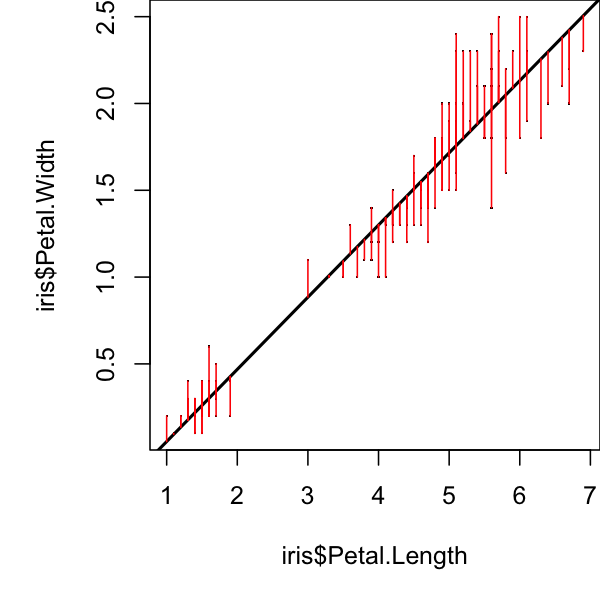

```r
par(mai=c(1,1,0,0))
plot(iris$Petal.Length, iris$Petal.Width, pch=".")
abline(results, lwd=2)

# Plot distances between points and the regression line (i.e. residuals)
predictedY <- predict(results)
segments(iris$Petal.Length, iris$Petal.Width, iris$Petal.Length, predictedY, col="red")
```

### Interpreting lm() Results Summary

- Residuals: The difference between the actual and predicted values
- Estimate: Regression coefficient estimates
- Std. Error: Measurement of the variability of the coefficient estimate. Lower is better
- t value: Coefficient score to describe the importance of predictor; used to calculate the p-value
- Pr(>|t|): Coefficient p-value. Probability the predictor is **NOT** relevant
- R-square: Score for evaluating how well the model fits the data. Higher is better. This can be adjusted for the number of predictors used in the model.
  - Values ~0.7 are of more interest, but there is no standard rule
- More information: http://blog.yhat.com/posts/r-lm-summary.html

### Predict Values for New Inputs to Regression Model

```r
new <- data.frame(Petal.Length=seq(-3, 3, 0.5))
predict(results, new)
```

```
         1          2          3          4          5          6
-1.6103418 -1.4024641 -1.1945864 -0.9867086 -0.7788309 -0.5709532
         7          8          9         10         11         12
-0.3630755 -0.1551978  0.0526799  0.2605576  0.4684353  0.6763130
        13
 0.8841907
```

### Multiple Regression

```r
formula <- "Sepal.Width ~ Petal.Length + Petal.Width"

y <- iris$Sepal.Width
fit <- lm(as.formula(formula), data=iris[,1:4])
summary(fit)
```

```
Call:
lm(formula = as.formula(formula), data = iris[, 1:4])

Residuals:
     Min       1Q   Median       3Q      Max
-1.06198 -0.23389  0.01982  0.20580  1.13488

Coefficients:
             Estimate Std. Error t value Pr(>|t|)
(Intercept)   3.58705    0.09373  38.272  < 2e-16 ***
Petal.Length -0.25714    0.06691  -3.843  0.00018 ***
Petal.Width   0.36404    0.15496   2.349  0.02014 *
---
Signif. codes:  0 '***' 0.001 '**' 0.01 '*' 0.05 '.' 0.1 ' ' 1

Residual standard error: 0.3893 on 147 degrees of freedom
Multiple R-squared:  0.2131,    Adjusted R-squared:  0.2024
F-statistic:  19.9 on 2 and 147 DF,  p-value: 2.238e-08
```

### Plotting Multiple Regression

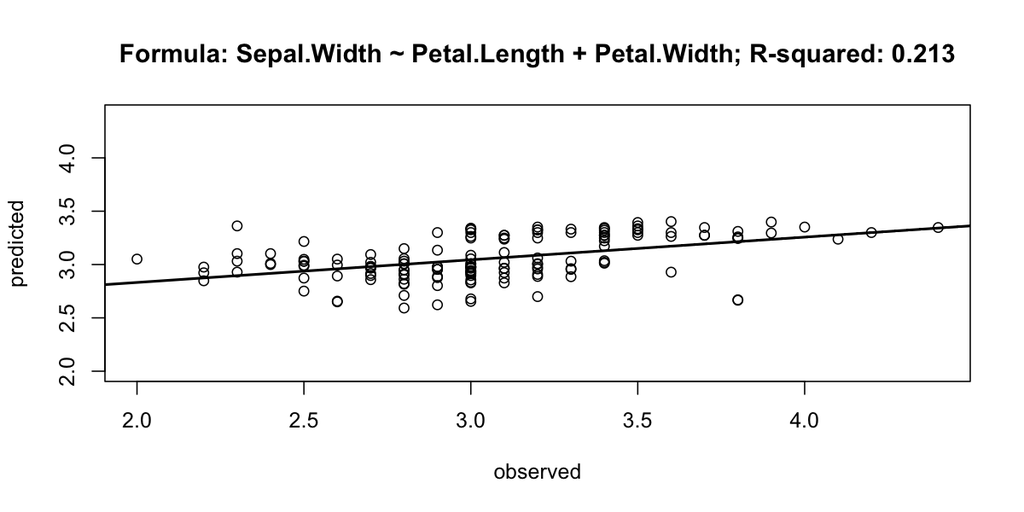

```r
pred <- predict(fit)

# Add regression between predicted and observed
fit2 <- lm(pred ~ y)

# Plot predicted versus observed
title <- paste0("Formula: ", formula, "; R-squared: ", round(summary(fit2)$r.squared, 3))

plot(y, pred, xlim=range(c(y, pred)), ylim=range(c(y, pred)), xlab="observed", ylab="predicted", main=title)

# Add regression line
abline(fit2, lwd=2)
```

### Some Issues with Regression

- Missing Data: What if your data has missing values?
  - Imputation can be used to fill in missing values using other data points
- Too many predictors versus the number of samples
  - The “Curse of Dimensionality” (later slide)
  - Regularized regression methods can be used to select features to be included in the model
- Overfitting: Will your model work on other datasets?
  - Excessively complex models (e.g. having too many predictors) can have poor predictive performance when tested on new data
  - Regularized regression methods have properties to avoid overfitting

### Missing Data

- By default, `lm()` removes rows that contain missing values
- An alternative is imputation to fill in missing values
  - `impute` imputes using K-Nearest Neighbors (KNN)
  - Step 1: Identify K number of neighbors based on Euclidean distance
  - Step 2: Average the values of the neighbors and replace the missing value

### Basic Rules for Imputation

- Should be done when the number of missing values is small
  - A safe maximum threshold is 5% of the total for large datasets
- Should be done when the imputed values are plausible for the missing values
- Should be done when it is assumed that the missing values occur at random
  - If missing values do not occur at random, the data collection should be investigated and/or the values should be dropped

### The "Curse of Dimensionality"

- If the number of predictors is greater than the number of samples, it will not be possible to estimate relevant regression parameters in the full model.
  - This is due to the degrees of freedom in the system.
  - There are \( n \) observations and \( p+1 \) parameters (one regression coefficient for each predictor plus the intercept) leaving \( n-p-1 \) degrees of freedom.
  - Increasing the sample size provides more information about the population test.
  - Increasing the number of predictors in the resulting model lowers the degrees of freedom available to estimate the variability of the predictors; this increases the variance of the regression coefficient estimates and reduces confidence in the model.

### LASSO, Ridge, and Elastic Net Regularized Regression

- Least Absolute Shrinkage and Selection Operator (LASSO): Tends to produce sparse (i.e. few predictors) whereby the algorithm selects an arbritary predictor among a set of correlated ones
- Ridge: Tends to select all correlated predictors with their coefficient values equal to each other
- Elastic Net (EN): Blends the concepts of LASSO and Ridge regression to attempt to create a model that is both sparse, but also includes correlated predictors
  - EN parameter \( \alpha=1 \) represents LASSO regression, while \( \alpha=0 \) approaches Ridge regression
- LASSO, Ridge, and Elastic Net regression are available from the `glmnet` R package
  - Sousa FG et al. DNA damage response alterations and its relation with drug activity across the NCI-60. DNA Repair (2015) for example usage of `glmnet` and Elastic Net

### Clustering

- Goal: Divide data into groups (clusters), so that group members are more “similar” to each other than to members outside the group
  - Example: Cluster a set of drugs. For drugs without a known mechanism of action (MOA), predict a potential MOA based on how the unknown MOA drugs cluster with known MOA drugs
- Clustering differs from classification in that in classification we have known groups

### Hierarchical Clustering

- R uses an agglomerative (bottom-up) clustering approach
  - Alternative: Divise (top-down) is similiar to agglomerative, but in reverse
- Algorithm
  1. All points start in their own clusters
  2. At each iteration merge the 2 most similar structures
  3. Stop if there is a single cluster containing all points, else go to Step 2

### Hierarchical Clustering Example

- Heatmap shows the expression of 20 oncogenes from 20 NCI-60 celllines

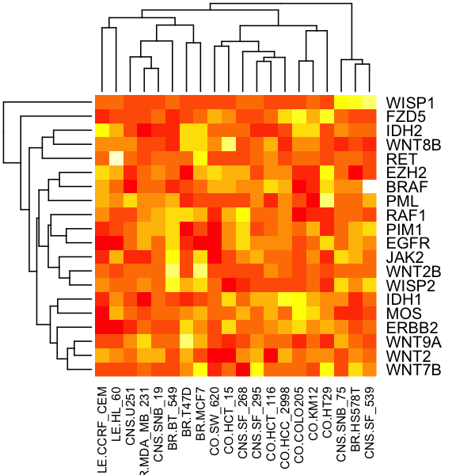

```r
dat <- read.table("files/heatmapExample.txt", sep="\t", header=TRUE)
mat <- as.matrix(dat); heatmap(mat, cexCol=0.75)
```

### Cluster Similarity (Linkage)

- Distances between clusters are calculated to determine cluster similarity
- Options of Cluster Linkage Distances
  - Single: Distance between two clusters is defined by the distance between the two closest points.
  - Average: Average of all pairwise distances between the points in two clusters
  - Complete: Distance between two clusters is defined by the distance between the two farthest points.
- `hclust()` used by `heatmap()` in R uses the “complete” method by default

### K-Means Clustering

- Algorithm
  1. A user-selected (\( k \)) number of means are randomly generated from the data
  2. \( k \) clusters are created by grouping data points to the nearest mean.
  3. The centroid of the clusters becomes the new mean.
  4. Steps 2 and 3 are repeated until the clusters do not change anymore

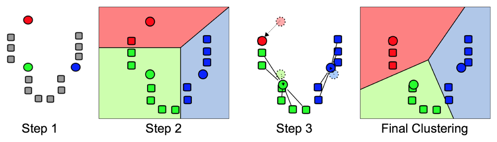

### K-Means Clustering Example

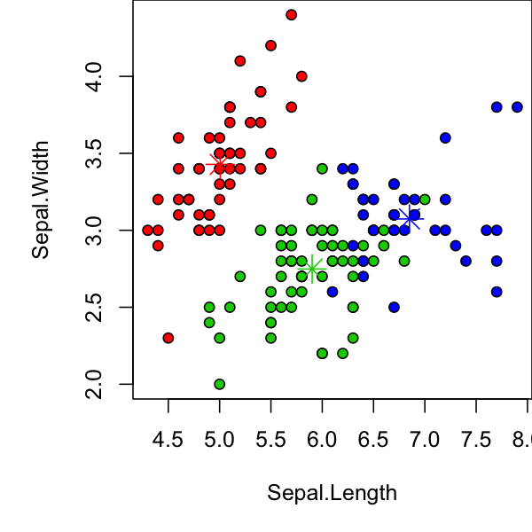

```r
# Retain only the numeric data in the iris dataset
iris_data <- iris[, 1:4]

# nstart: try multiple initial configurations and report the best one
kc <- kmeans(iris_data, 3, nstart=25)

par(mai=c(1,1,0,0))
plot(iris[c("Sepal.Length", "Sepal.Width")], bg=c("red","green3","blue")[kc$cluster], pch=21)
points(kc$centers[,c("Sepal.Length", "Sepal.Width")], col=c("red","green3","blue"), pch=8, cex=2)
```

### Determine K-Means Cluster Quality

```r
library(cluster)
dataDist <- dist(iris_data)
si <- silhouette(kc$cl, dataDist)
```

- Silhouette Plot
  - Horizontal barplot is the goodness of fit of sample within the cluster
  - Longer is better
  - Rightmost number, \( S_i \), is average length
- Average Silhouette Guidelines
  - 0.71-1.0: Strong clustering
  - 0.51-0.70: Reasonable clustering
  - < 0.50: Weak clustering

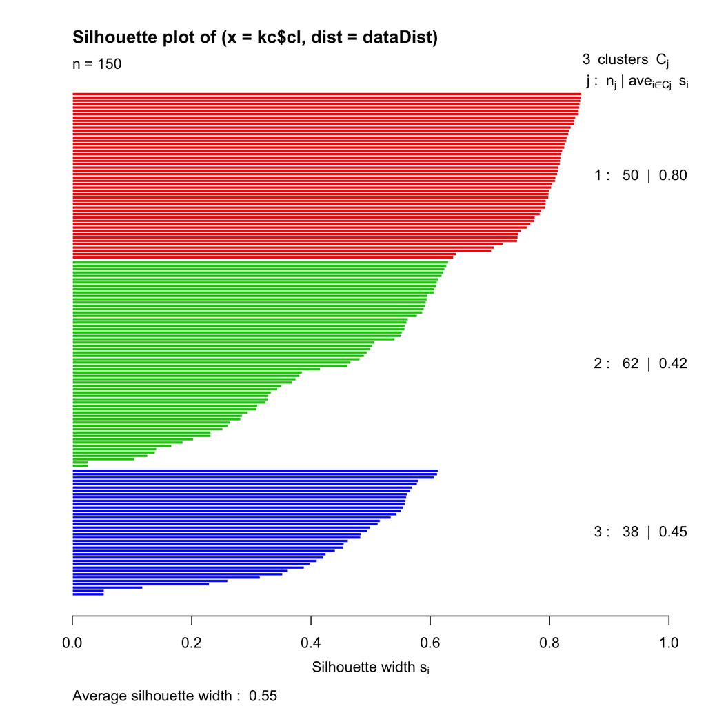

```r
plot(si, col = c("red", "green3", "blue"))
```

### Selecting k with Average Silhouette

```r
library(cluster)
kMax <- 15
avgSi <- rep(0, kMax)

# Average silhouette width
# k: 2 to 15
for(i in 2:kMax){
  results <- kmeans(iris_data, centers=i)
  si <- silhouette(results$cluster, dist(iris_data))
  avgSi[i] <- mean(si[, "sil_width"])
}
```

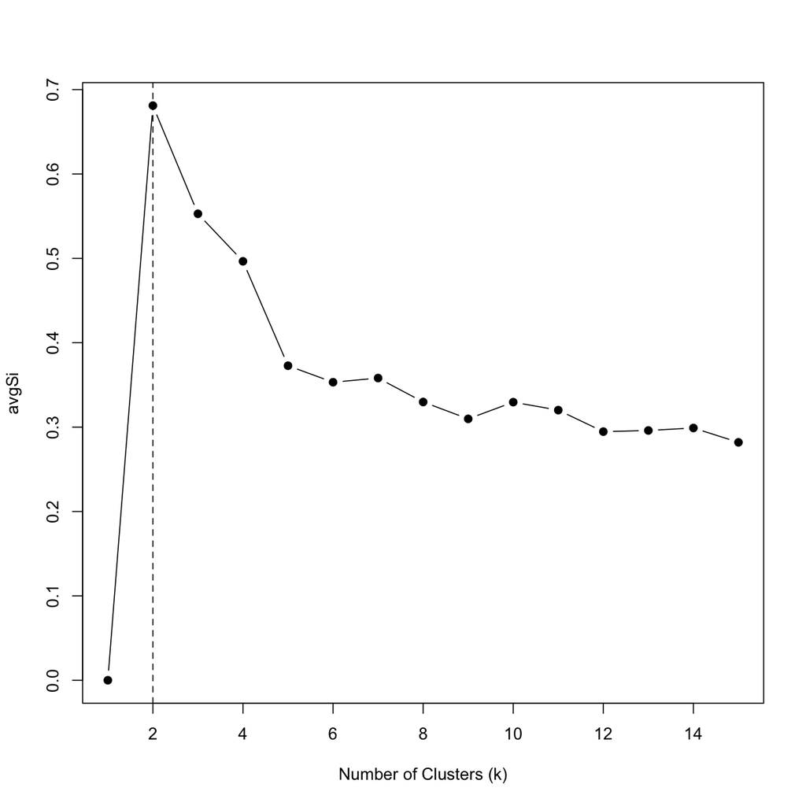

```r
plot(1:kMax, avgSi, type="b", pch=19, xlab="Number of Clusters (k)")
abline(v=which.max(avgSi), lty=2)
```

### Compare Known Classes with Clusters

```r
table(iris$Species, kc$cluster)
```

```
              1  2  3
  setosa     50  0  0
  versicolor  0 48  2
  virginica   0 14 36
```

### Differences between Hierarchical and K-Means Clustering

- Clusters
  - K-means produces a single set of clusters
  - Hierarchical produces different clusters depending on where the tree is cut
- Cluster Number
  - K-means requires the number clusters to be set
  - Hierarchical clustering does not require the number of clusters to be set
- Speed
  - K-means is faster than hierarchical clustering

### Dimensionality Reduction

- Goal: Seeks to reduce the dimensions of the data without losing (much) information.
  - This is possible if many predictors are correlated with one another, and therefore redundant.
- Principal Component Analysis is a method for dimension reduction

### What is Principal Component Analysis (PCA)

- Goal: PCA seeks to simplify a multi-dimensional (e.g. one with 3+ predictors (features)) dataset
  - Used for feature extraction
  - May reveal clusters and help validate clustering results
- Example: We have a dataset with 20 dimensions and it may be interesting to plot the data in two dimensions
- Results:
  - Loadings: Weights for the original values to get the component scores
  - Component Scores: Transformed values for a given point
- `prcomp` and `princomp` can do PCA in R; `prcomp` is the advised function

### What are Principal Components?

- Each “principal component” (PC) is an axis that captures the most variance
  - Variance is a measure of the spread of data points; standard deviation is the square root of variance
  - Each PC is a combination of the original variables scaled by a coefficient
  - Every PC explains some variance
  - Each additional PC explains less variance than the previous one
- New coordinate axes are constrained to be perpendicular, so the data are de-correlated

### PCA Example

- Using scale=TRUE is advisable
- `prcomp` first transforms the data by centering and scaling
  - Centering is done by subtracting the column means
  - Scaling is done by dividing the (centered) columns of \( x \) by their standard deviations

```r
iris_data <- iris[, 1:4]

pcaResult <- prcomp(iris_data, scale=TRUE)
summary(pcaResult)
```

```
Importance of components:
                          PC1    PC2     PC3     PC4
Standard deviation     1.7084 0.9560 0.38309 0.14393
Proportion of Variance 0.7296 0.2285 0.03669 0.00518
Cumulative Proportion  0.7296 0.9581 0.99482 1.00000
```

### PCA Example Plots

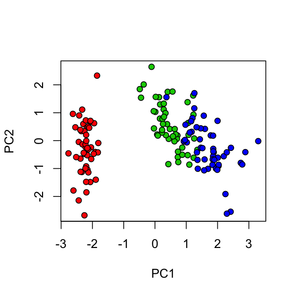

```r
# First 2 principal components (PC)
plot(pcaResult$x, pch=21, bg=c("red","green3","blue")[unclass(iris$Species)])
```

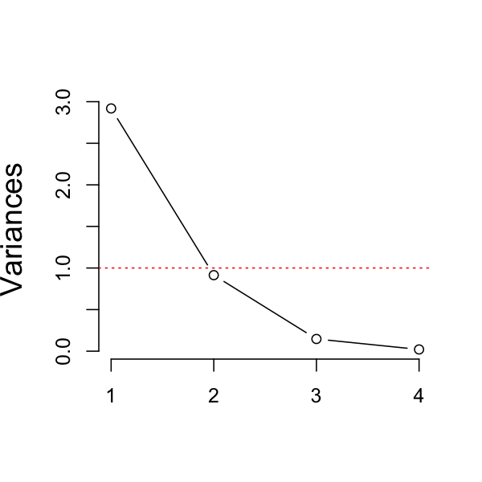

```r
# PC variances
plot(pcaResult, type="line", cex.lab=1.5, cex.main=1.5, main="")
abline(h=1, lty=3, col="red")
```

### Recovering the Original Data

```r
# Weights (known as loadings)
pcaResult$rotation
```

```
                    PC1         PC2        PC3        PC4
Sepal.Length  0.5210659 -0.37741762  0.7195664  0.2612863
Sepal.Width  -0.2693474 -0.92329566 -0.2443818 -0.1235096
Petal.Length  0.5804131 -0.02449161 -0.1421264 -0.8014492
Petal.Width   0.5648565 -0.06694199 -0.6342727  0.5235971
```

```r
# Original
iris_data[1,]
```

```
  Sepal.Length Sepal.Width Petal.Length Petal.Width
1          5.1         3.5          1.4         0.2
```

```r
# Transformed
pcaResult$x[1,]
```

```
        PC1         PC2         PC3         PC4
-2.25714118 -0.47842383  0.12727962  0.02408751
```

```r
# Recovered
tmp <- t(t(pcaResult$x %*% t(pcaResult$rotation)) * pcaResult$scale + pcaResult$center)
tmp[1,]
```

```
Sepal.Length  Sepal.Width Petal.Length  Petal.Width
         5.1          3.5          1.4          0.2
```

### Visualizing PCA Results with Biplots

- Visualizes the magnitude and sign of each feature's contribution to a PC
- Visualizes each observation in terms of PCs
- Closeness equals similarity for points and vectors

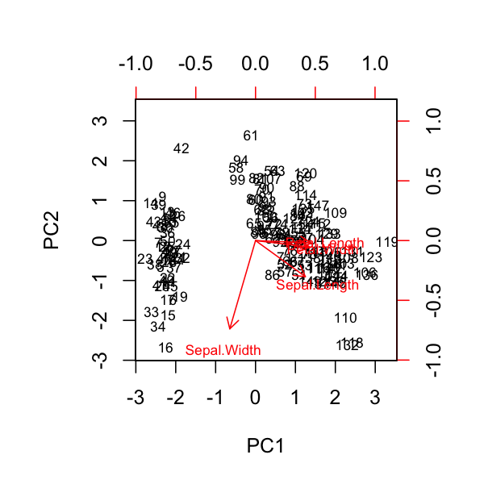

```r
biplot(pcaResult, scale=0, cex=.7)
```

### Correlations between Vectors

## Feature to Principal Component Correlations

```r
cor(iris_data, pcaResult$x)
```

```
                    PC1         PC2         PC3         PC4
Sepal.Length  0.8901688 -0.36082989  0.27565767  0.03760602
Sepal.Width  -0.4601427 -0.88271627 -0.09361987 -0.01777631
Petal.Length  0.9915552 -0.02341519 -0.05444699 -0.11534978
Petal.Width   0.9649790 -0.06399985 -0.24298265  0.07535950
```

## Feature to Principal Component Contributions

```r
tmp <- abs(pcaResult$rotation)
sweep(tmp, 2, colSums(tmp), "/")
```

```
                   PC1        PC2        PC3        PC4
Sepal.Length 0.2691897 0.27110474 0.41346137 0.15281309
Sepal.Width  0.1391485 0.66321714 0.14042128 0.07223451
Petal.Length 0.2998493 0.01759269 0.08166552 0.46872700
Petal.Width  0.2918125 0.04808543 0.36445183 0.30622540
```

### How Many Principal Components Should be Kept?

- Kaiser criterion
  - Retain only principal components that with a variance greater than 1
  - The variance of every input variable is 1 (because the scaling/centering), therefore only retain PCs with “stronger” variances than individual variables.
  - Simple, but less advisable
- Scree Test
  - Find the place where the smooth decrease in the variances levels off
  - Multiple users may interpret the data different, unless trained the same

### Getting Help

- Cross-Validated Stats Exchange
  - Part of Stack Overflow
  - http://stats.stackexchange.com/
- Biostars
  - https://www.biostars.org